# 5. Statistische besluitvorming

## 4.2 Ongekende variantie

In echte voorbeelden is $\sigma$ ongekend en wordt het geschat op basis van de steekproef met behulp van de standaarddeviatie $S$.

- De vorige intervallen waren iets te klein omdat ze geen rekening hielden met de onzekerheid over de schatting van $S$.
- Als $n$ groot is, ligt $S$ in de buurt van $\sigma$.
- Vandaar dat ${(\bar{X} - \mu)}/{(S/\sqrt{n}) }$ ongeveer standaard normaal verdeeld is en
  $$\begin{equation*}
  \left[\bar{X} - z_{\alpha/2} \ \frac{S}{\sqrt{n}} , \bar{X} + z_{\alpha/2} \ \frac{S}{\sqrt{n}}\right]
  \end{equation*}$$
  is een geschatte $(1- \alpha)100\%$ CI voor $\mu$.
- Voor kleine steekproeven geldt dit niet meer (e.g. n=10)

De schatting van $S$ introduceert extra onzekerheid in de gestandaardiseerde waarde ${(\bar{X} - \mu)}/{(S/\sqrt{n})}$. Zijn distributie

- is nog steeds symmetrisch maar heeft zwaardere staarten dan de normale verdeling.
- Het hangt van $n$ af hoeveel zwaarder de staarten zijn
- is een (Student) $t$-verdeling met $n-1$ *vrijheidsgraden*.

### 4.2.1 T-verdeling

Formeel: Let $X_1, X_2, ..., X_n$ een onafhankelijke willekeurige steekproef zijn uit een normale verdeling $N(\mu, \sigma^2)$, dan volgt $(\bar{X} - \mu)/(S/\sqrt{n})$ een $t$-verdeling met $n-1$ vrijheidsgraden.

De densiteit van een t-verdeling kan worden berekend in R met de functie `dt`. Het heeft argumenten ‘x’ voor het kwantiel en ‘df’ voor de vrijheidsgraden.

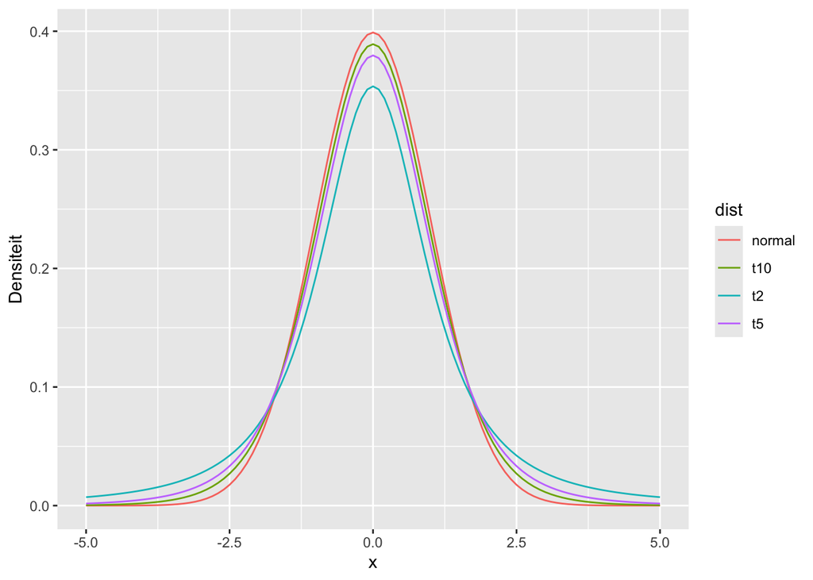

```r
grid <- seq(-5,5,.1)
densDist <- cbind(grid,dnorm(grid), sapply(c(2,5,10),dt,x=grid))
colnames(densDist) <- c("x","normal",paste0("t",c(2,5,10)))

densDist |>
  as.data.frame() |>
  gather(dist,dens,-x) |>
  ggplot(aes(x=x,y=dens,color=dist)) +
  geom_line() +
  xlab("x") +
  ylab("Densiteit")
```

t-verdelingen hebben zwaardere staarten dan de normale verdeling $\rightarrow$ grotere kantielen, dus bredere intervallen voor hetzelfde betrouwbaarheidsniveau.

- Dit geeft de extra onzekerheid weer voor het schatten van $S$.
- Als $n \rightarrow \infty$ dan $t(df) \rightarrow N(0,1)$
- kwantielen van de $t$-verdeling kunnen worden berekend in R met behulp van `qt`. bv. 95%, 97.5%, 99.5% kwantiel voor een t-verdeling met 14 vrijheidsgraden.

```r
qt(.975,df=14)
```

```
[1] 2.144787
```

```r
qt(c(.95,.975,.995),df=14)
```

```
[1] 1.761310 2.144787 2.976843
```

- Deze kwantielen kunnen gebruikt worden om de 90%, 95% and 99% CI te berekenen.
- 97.5% kwantiel2.14 van een t-verdeling met $n-1=14$ vrijheidsgraden is inderdaad groter dan die van een standaard normale verdeling 1.96.

### 4.2.2 Betrouwbaarheidsinterval gebaseerd op de t-verdeling

De $100\% (1-\alpha)$ CI voor het gemiddelde $\mu$ van een normaal verdeelde willekeurige variabele $X$ met ongekende variantie is

$$\begin{equation*}
\left[\bar{X} - t_{n-1, \alpha/2} \frac{s}{\sqrt{n}} , \bar{X} + t_{n-1,
\alpha/2} \frac{s}{\sqrt{n}}\right]
\end{equation*}$$

- We vervangen eenvoudig het $(1-\alpha/2)100\%$ kwantiel van de normale verdeling door die van de t-verdeling met $n-1$ vrijheidsgraden.

### 4.2.3 Captopril voorbeeld

95% CI voor de gemiddelde bloeddrukverandering wordt

```r
mean(captopril$deltaSBP) -  qt(.975,df=14)*sd(captopril$deltaSBP)/sqrt(15)
```

```
[1] -23.93258
```

```r
mean(captopril$deltaSBP) + qt(.975,df=14)*sd(captopril$deltaSBP)/sqrt(15)
```

```
[1] -13.93409
```

Het 99% CI is gegeven door

```r
mean(captopril$deltaSBP) -  qt(.995,df=14)*sd(captopril$deltaSBP)/sqrt(15)
```

```
[1] -25.87201
```

```r
mean(captopril$deltaSBP) + qt(.995,df=14)*sd(captopril$deltaSBP)/sqrt(15)
```

```
[1] -11.99466
```

Merk op dat nul buiten het interval ligt en dat het gehele interval negatief is, wat aangeeft dat er gemiddeld een groot effect is van het toedienen van captopril op de bloeddruk van patiënten met hypertensie.

### 4.2.4 Interpretatie van het betrouwbaarheidsinterval

- We zullen opnieuw steekproeven trekken van de grote NHANES studie en deze keer BI’s bestuderen voor log2-cholesterol steekproefwaarden. We voeren eerst herhaalde experimenten uit met steekproefgrootte 10.

```r
res$n <- as.character(res$n) |>
  as.double(res$n)

res$ll <- res$mean-qt(0.975,df=res$n-1)*res$se
res$ul <- res$mean+qt(0.975,df=res$n-1)*res$se

mu <- fem$DirectChol|>log2()|>mean()

res$inside <- res$ll<=mu & mu<=res$ul
res$n <- as.factor(res$n)

res |>
  group_by(n) |>
  summarize(coverage=mean(inside)) |>
  spread(n,coverage)
```

```
# A tibble: 1 × 3
   `10`  `50` `100`
  <dbl> <dbl> <dbl>
1 0.949 0.947 0.959
```

We zien dat de omvang van de intervallen nu worden gecontroleerd op hun nominale betrouwbaarheidsniveau van 95%.

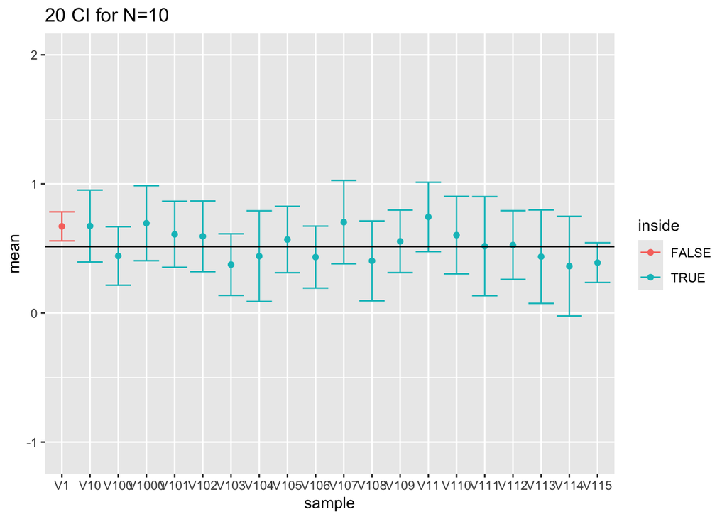

```r
res |>
  filter(n==10) |>
  slice(1:20) |>
  ggplot(aes(x=sample,y=mean,color=inside)) +
  geom_point() +
  geom_errorbar(
    aes(ymin=mean-qt(0.975,df=9)*se,
    ymax=mean+qt(0.975,df=9)*se))+
  geom_hline(yintercept = fem$DirectChol |> log2() |> mean()) +
  ggtitle("20 CI for N=10") +
  ylim(range(fem$DirectChol |> log2()))
```

Opdracht

Maak plot voor simulatie studie met grotere steekproefgrootte. Welke impact heeft dit op de BIs?

[figure not shown]

## 4.3 Rapporteren?

- Rapporteer altijd de onzekerheid over de resultaten!
- Conclusies op basis van een puntschatting kunnen erg misleidend zijn.
- Bij een statistische analyse rapporteren we daarom altijd betrouwbaarheidsintervallen
- Ze zijn klein genoeg om informatief te zijn, maar bijna nooit misleidend
- Ze vormen een goede afweging tussen statistische significantie en biologische relevantie.
- Rapporteer altijd de onzekerheid op de resultaten!
- Bij een statistische analyse rapporteren we daarom altijd betrouwbaarheidsintervallen
- De intervallen zijn klein genoeg om informatief te zijn, maar bijna nooit misleidend
- Ze vormen een goede afweging tussen statistische significantie en biologische relevantie.
- We concluderen dat de populatieparameter in het interval ligt en weten dat deze stelling geldt met een probabiliteit van 95% voor willekeurige steekproeven.

### 4.3.1 Captopril voorbeeld

We concluderen dat de bloeddruk gemiddeld met 18.9mmHg vermindert na toediening van captopril (95% CI [-23.9,-13.9]mmHg).

Op basis van deze resultaten is het duidelijk dat de behandeling een sterke bloeddrukdaling veroorzaakt bij patiënten met hypertensie.

# 5 Hypothese testen

## 5.1 Captopril voorbeeld:

Onderzoekers willen beoordelen of het medicijn captopril de bloeddruk verlaagt bij patiënten met hypertensie.

- Heeft het toedienen van captopril wel of geen effect op de systolische bloeddruk?
- Het ligt niet voor de hand om dergelijke conclusies te trekken op basis van een kleine steekproef
- Het is onzeker of we de observaties in de steekproef naar de populatie kunnen veralgemenen!
- Is het schijnbaar gunstige effect systematisch of willekeurig?

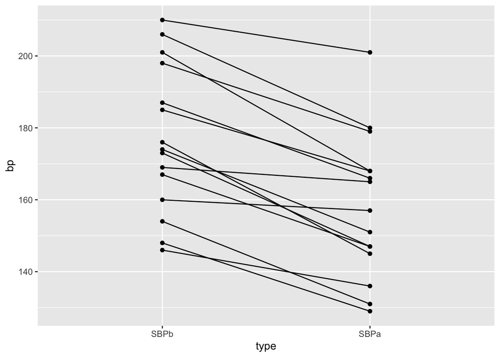

```r
captoprilTidy |>
  filter(type%in%c("SBPa","SBPb")) |>
  mutate(type=factor(type,levels=c("SBPb","SBPa"))) |>
  ggplot(aes(x=type,y=bp)) +
  geom_line(aes(group = id)) +
  geom_point()
```

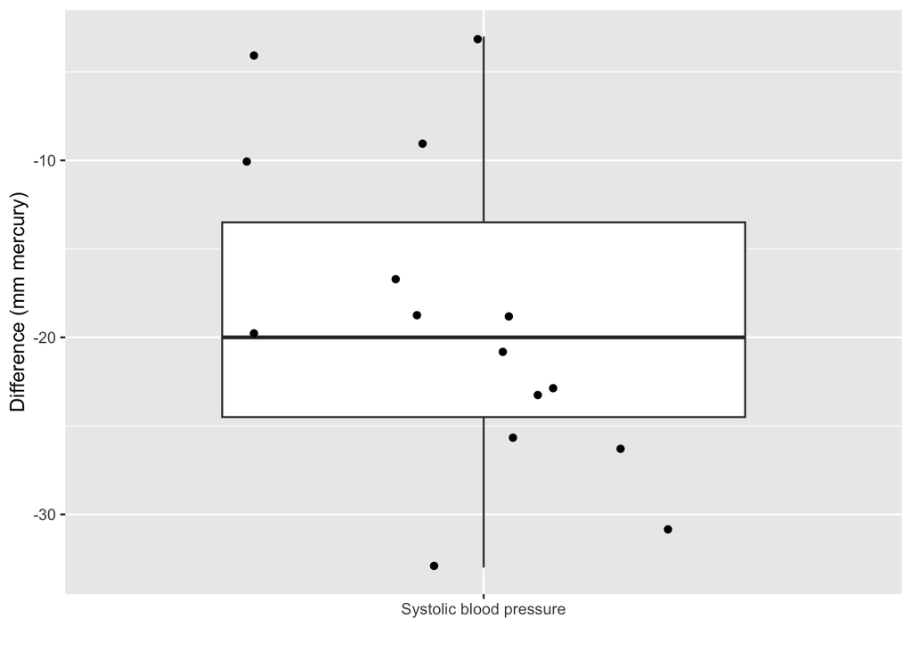

```r
captopril$deltaSBP <- captopril$SBPa-captopril$SBPb
captopril|>
  ggplot(aes(x="Systolic blood pressure",y=deltaSBP)) +
  geom_boxplot(outlier.shape=NA) +
  geom_point(position="jitter")+
  ylab("Difference (mm mercury)") +
  xlab("")
```

- Het gemiddelde bloeddrukverschil $\bar X$ is een natuurlijke basis om onze beslissingen op te baseren.

$$\bar x\text{=-18.93 (s=9.03, SE=2.33)}$$

- Het is niet voldoende dat $\bar{x}< 0$ om te concluderen dat de systolische bloeddruk gemiddeld lager is bij toediening van Captopril *op het niveau van de gehele populatie*.
- Om het effect dat we in de steekproef waarnemen te veralgemenen naar de populatie, moet het voldoende groot zijn.
- Maar hoe groot?

### 5.1.1 Hypothese testen

- Voor dit doel zijn statistische hypothesetests ontwikkeld
- Deze geven een zwart/wit antwoord
- Het is bijna onmogelijk om een wetenschappelijke publicate te lezen zonder resultaten van statistische testen
- Volgens het *falsificatie principe* van Popper kunnen we nooit een hypothese bewijzen op basis van gegevens.
  - Daarom introduceren we twee hypothesen: een nulhypothese $H_0$ en een alternatieve hypothese $H_1$.
  - We zullen proberen de nulhypothese te ontkrachten op basis van de statistische test.

#### 5.1.1.1 Captopril

- Op basis van de steekproef kunnen we niet bewijzen dat er een effect is van het toedienen van captopril ($H_1$, alternatieve hypothese).
- We veronderstellen daarom dat er geen effect is van captopril
  - We noemen dit de nulhypothese $H_0$.
  - Falsify (“probeer te ontkrachten”) de $H_0$.
  - Hoe waarschijnlijk is het om een effect waar te nemen dat minstens zo groot is als wat we in de steekproef in een willekeurige steekproef hebben gezien als $H_0$ waar is?

#### 5.1.1.2 Permutatie test

- Onder $H_0$ zijn de bloeddrukmetingen voor en na toediening van captopril twee “base line” bloeddrukmetingen voor een patiënt
- Onder H$_0$ kunnen we de bloeddrukmetingen voor iedere patiënt in willekeurige volgorde plaatsen (permuteren).

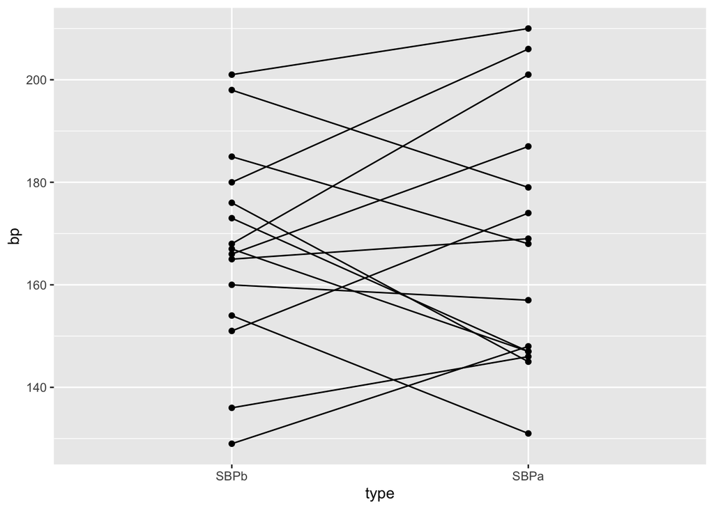

```r
set.seed(35)
captoprilSamp <- captopril
perm <- sample(c(FALSE, TRUE), 15, replace = TRUE)
captoprilSamp$SBPa[perm] <- captopril$SBPb[perm]
captoprilSamp$SBPb[perm] <- captopril$SBPa[perm]
captoprilSamp$deltaSBP <- captoprilSamp$SBPa-captoprilSamp$SBPb
captoprilSamp |>
  gather(type, bp, -id) |>
  filter(type %in% c("SBPa","SBPb")) |>
  mutate(type = factor(type, levels = c("SBPb", "SBPa")))|>
  ggplot(aes(x = type,y = bp)) +
  geom_line(aes(group = id)) +
  geom_point()
```

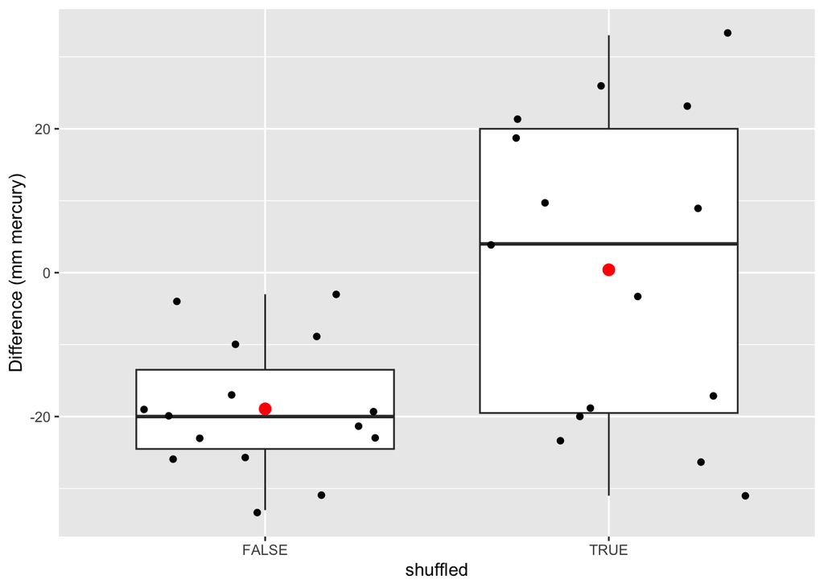

```r
data.frame(
  deltaSBP = c(captopril$deltaSBP,captoprilSamp$deltaSBP),
  shuffled=rep(c(FALSE,TRUE),each=15)
  ) |>
  ggplot(aes(x = shuffled, y = deltaSBP)) +
  geom_boxplot(outlier.shape = NA) +
  geom_point(position = "jitter")+
  stat_summary(
    fun.y = mean,
    geom = "point",
    shape = 19,
    size = 3,
    color = "red",
    fill = "red") +
  ylab("Difference (mm mercury)")
```

We permuteren opnieuw

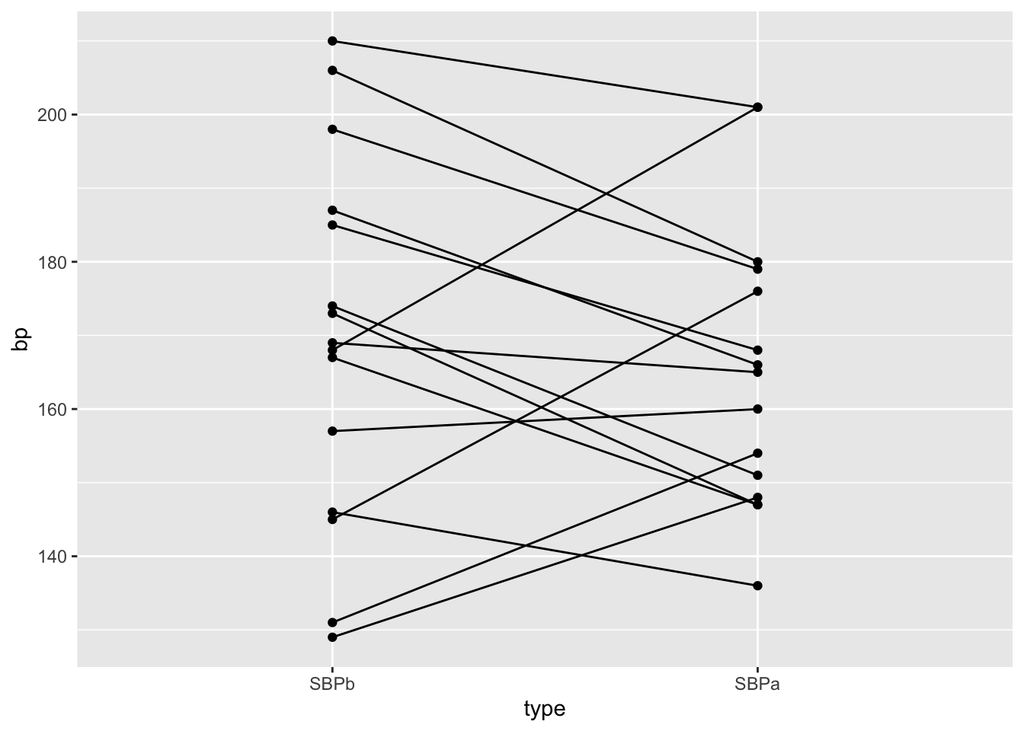

```r
captoprilSamp <- captopril
perm <- sample(c(FALSE,TRUE), 15, replace = TRUE)
captoprilSamp$SBPa[perm] <- captopril$SBPb[perm]
captoprilSamp$SBPb[perm] <- captopril$SBPa[perm]
captoprilSamp$deltaSBP <- captoprilSamp$SBPa-captoprilSamp$SBPb
captoprilSamp |>
  gather(type, bp, -id) |>
  filter(type %in% c("SBPa","SBPb")) |>
  mutate(type = factor(type, levels = c("SBPb", "SBPa")))|>
  ggplot(aes(x = type,y = bp)) +
  geom_line(aes(group = id)) +
  geom_point()
```

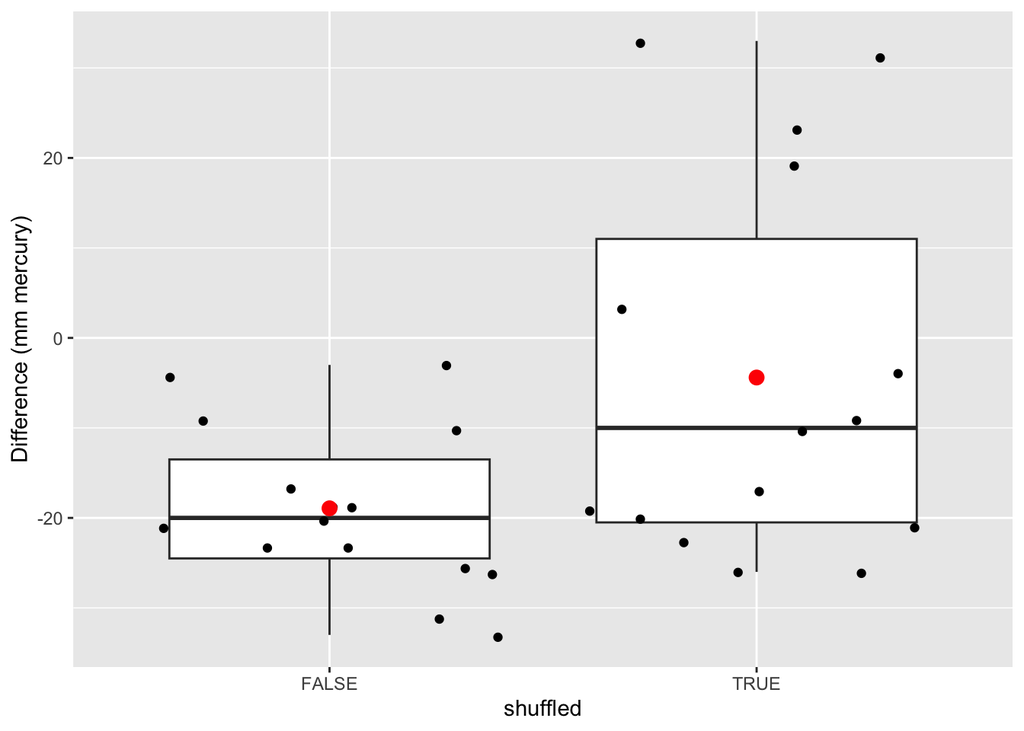

```r
data.frame(
  deltaSBP = c(captopril$deltaSBP,captoprilSamp$deltaSBP),
  shuffled=rep(c(FALSE,TRUE),each=15)
  ) |>
  ggplot(aes(x = shuffled, y = deltaSBP)) +
  geom_boxplot(outlier.shape = NA) +
  geom_point(position = "jitter")+
  stat_summary(
    fun.y = mean,
    geom = "point",
    shape = 19,
    size = 3,
    color = "red",
    fill = "red") +
  ylab("Difference (mm mercury)")
```

- Er zijn $2^{15}$ = 32768 mogelijke permutaties!
- We hoeven in principe alleen de tekens van de waargenomen bloeddrukverschillen $x$ te wisselen als we permuteren.

```r
permH <- expand.grid(
  replicate(
    15,
    c(-1,1),
    simplify=FALSE)
  ) |>
  t()

permH[,1:5]
```

```
      [,1] [,2] [,3] [,4] [,5]
Var1    -1    1   -1    1   -1
Var2    -1   -1    1    1   -1
Var3    -1   -1   -1   -1    1
Var4    -1   -1   -1   -1   -1
Var5    -1   -1   -1   -1   -1
Var6    -1   -1   -1   -1   -1
Var7    -1   -1   -1   -1   -1
Var8    -1   -1   -1   -1   -1
Var9    -1   -1   -1   -1   -1
Var10   -1   -1   -1   -1   -1
Var11   -1   -1   -1   -1   -1
Var12   -1   -1   -1   -1   -1
Var13   -1   -1   -1   -1   -1
Var14   -1   -1   -1   -1   -1
Var15   -1   -1   -1   -1   -1
```

- We zullen dit voor alle mogelijke permutaties doen en we zullen het gemiddelde bijhouden.

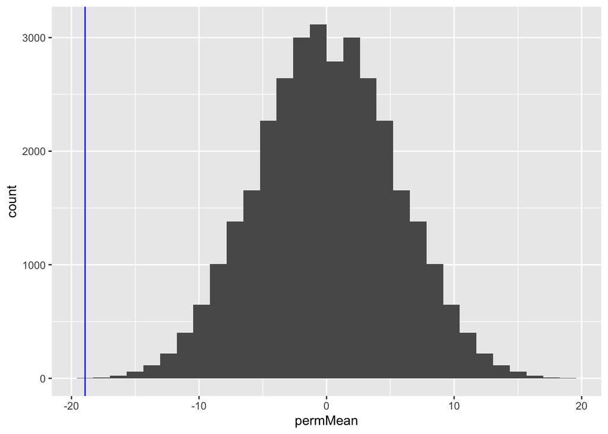

```r
#calculate the means for the permuted data
muPerm <- colMeans(permH*captopril$deltaSBP)
data.frame(permMean = muPerm) |>
  ggplot(aes(x=permMean)) +
  geom_histogram() +
  geom_vline(
    xintercept = mean(captopril$deltaSBP),
    col = "blue")
```

```r
sum(muPerm <= mean(captopril$deltaSBP))
```

```
[1] 1
```

```r
mean(muPerm <= mean(captopril$deltaSBP))
```

```
[1] 3.051758e-05
```

- We zien dat maar 1 van de gemiddelden die werden verkregen onder $H_0$ (door permutatie) zo extreem was als het steekproefgemiddelde dat we in de captopril-studie hebben waargenomen.
- Dus de kans om een bloeddrukdaling waar te nemen die groter of gelijk is dan die in de captopril-studie in een willekeurige steekproef onder de nulhypothese, is 1 op de 32768.

We hebben dus sterk bewijs dat $H_0$ onjuist is en daarom verwerpen we $H_0$ en concluderen $H_1$: het toedienen van captopril heeft een effect op de bloeddruk van patiënten met hypertensie.

### 5.1.2 Pivot

- In de praktijk gebruiken we altijd statistieken die de effectgrootte (gemiddeld verschil) afwegen tegen ruis (standaard error)
- Als we de nulhypothese ontkrachten, standaardiseren we het gemiddelde rond $\mu_0 = 0$ het gemiddelde onder $H_0$

$$t=\frac{\bar X-\mu_0}{se_{\bar X}}$$

- Voor het Captopril voorbeeld wordt dit:
  $$\frac{-18.93-0}{2.33}=-8.12$$

We bepalen nu de nulverdeling van teststatistiek t met permutatie.

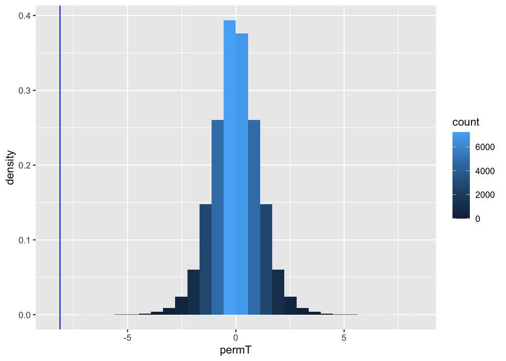

```r
deltaPerms <- permH*captopril$deltaSBP
tPerm <- colMeans(deltaPerms)/(apply(deltaPerms,2,sd)/sqrt(15))
tOrig <- mean(captopril$deltaSBP)/sd(captopril$deltaSBP)*sqrt(15)

tPermPlot <- data.frame(permT = tPerm) |>
  ggplot(aes(x=permT)) +
  geom_histogram(aes(y = ..density.., fill = ..count..)) +
  geom_vline(xintercept = tOrig,col = "blue")
tPermPlot
```

- Opnieuw heeft slechts 1 van de permutaties een t-statistiek die zo extreem is als de statistiek die wordt waargenomen in de captopril-studie.

Wanneer er geen effect van captopril is, is het bijna onmogelijk om een teststatistiek te verkrijgen die zo extreem is als degene die werd waargenomen ( t=-8.12).

- De kans om een grotere bloeddrukdaling waar te nemen dan degene die we in onze steekproef hebben waargenomen in een willekeurige steekproef onder $H_0$ is 1/32768.
- We noemen deze kans de *p-waarde*.
- Het meet de sterkte van het bewijs tegen de nulwaarde: hoe kleiner de p-waarde, hoe meer bewijs we hebben dat de nulwaarde niet waar is.
- De verdeling heeft een mooie klokvorm.

### 5.1.3 Hoe beslissen we?

Wanneer is de p-waarde klein genoeg om te concluderen dat er sterk bewijs is tegen de nulhypothese?

- We werken doorgaans met een significantieniveau van $\alpha = 0,05$
- We stellen dat we de test hebben uitgevoerd op het significantieniveau van 5%

### 5.1.4 Permutatietests zijn computationeel veeleisend

- Kunnen we beoordelen hoe extreem de bloeddrukdaling was zonder permutatie?
- We weten dat de bloeddrukverschillen ongeveer normaal verdeeld zijn, dus

$$t=\frac{\bar X - \mu}{se_{\bar X}}$$

volgt een t-verdeling (met 14 vrijheidsgraden voor het Captopril voorbeeld).

- Onder H$_0$ $\mu=0$ en
  $$t=\frac{\bar X-0}{se_{\bar X}}\sim f_{T,14}$$

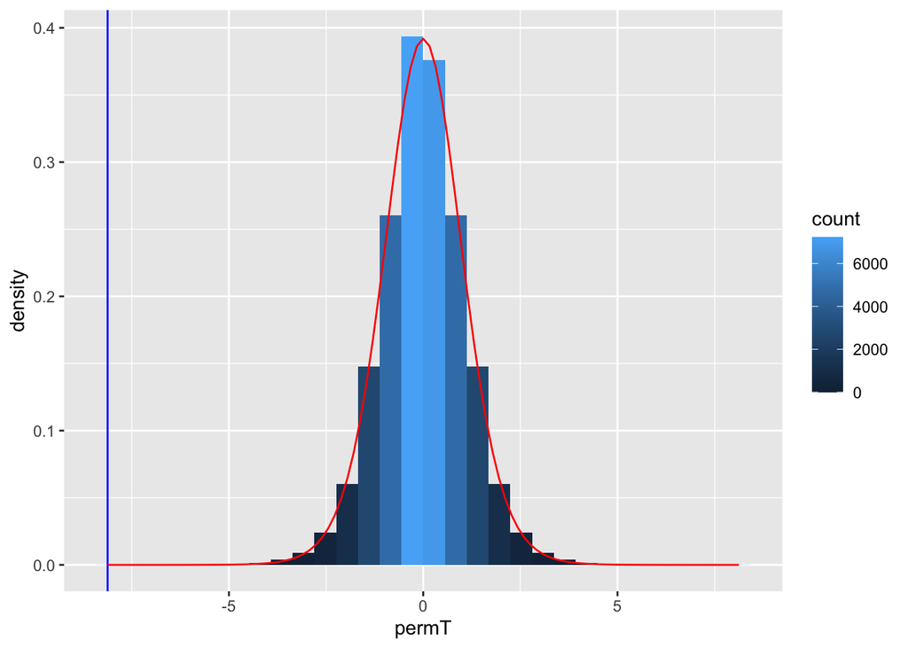

```r
tPermPlot +
  stat_function(
    fun = dt,
    color = "red",
    args = list(df=14))
```

- Merk op dat de permutatie-nulverdeling inderdaad overeenkomt met een t-verdeling met 14 vrijheidsgraden.
- Zodat we de statistische test kunnen uitvoeren met behulp van statistische modellen van de gegevens.
- Hiervoor moeten we assumpties maken, die we verifiëren in de data exploratie.

## 5.2 Hypotheses

Vertaal de onderzoeksvraag naar een nulhypothese ($H_0$) en een alternatieve hypothese ($H_1$)

Eerst moeten we de onderzoeksvraag vertalen naar een geparametriseerd statistisch model.

- Uit het experimentele ontwerp volgt dat
  $$X_1,...,X_n \text{ i.i.d } f(X),$$
  met $f(X)$ de dichtheidsfunctie van bloeddrukverschillen.
- **vereenvoudig**: neem aan dat $f(X)$ gekend is met uitzondering van een eindig dimensionale set parameters $\mathbf{\theta}$ die nog moet worden geschat (parametrisch statistisch model).

### 5.2.1 Captopril voorbeeld

$X \sim N(\mu,\sigma^2)$ with $\mathbf{\theta}=(\mu,\sigma^2)$, the mean $\mu$ and variance $\sigma^2$.

De onderzoeksvraag is nu vertaald in termen van de gemiddelde bloeddrukdaling:: $\mu = E_f[X]$.

De **alternatieve hypothese** is geformuleerd in termen van een parameter van $f(X)$ moet uitdrukken wat de onderzoekers met het onderzoek willen bewijzen.

- hier:
  $$H_1: \mu<0.$$
  Gemiddeld daalt de bloeddruk van patiënten met hypertensie na toediening van captopril.

De **nul hypothese** drukt over het algemeen een nulvoorwaarde uit, d.w.z wanneer er niets uitzonderlijks gebeurt.

- Onderzoekers proberen doorgaans via empirisch onderzoek aan te tonen dat het observeren van de gegevens onder de nul hoogst onwaarschijnlijk is, zodat ze de nulhypothese kunnen verwerpen: **Falsificatie principe**.
- De **nul hypothese wordt doorgaans uitgedrukt met dezelfde modelparameter als die wordt gebruikt voor $H_1$.**
- Hier:
  $$H_0 : \mu=0$$
  d.w.z. gemiddeld blijft de systolische bloeddruk ongewijzigd na toediening van captopril.

## 5.3 Test-statistiek

Zodra de populatie, de parameters en $H_0$ en $H_1$ zijn bepaald, volgt men bij hypothesetesten de volgende rationale:

Construeer een teststatistiek zodat deze

1. het bewijs meet in de steekproef,
2. tegen de nulhypothese, en
3. in het voordeel van de alternatieve hypothese.

Een teststatistiek moet dus een functie zijn van de waarnemingen in de steekproef.

### 5.3.1 Captopril voorbeeld

$$T=\frac{\bar{X}-\mu_0}{\text{SE}_{\bar X}}$$
Met $\mu_0=0$ onder $H_0$

Opnieuw

- Als $H_0$ geldt, is er geen effect van captopril op de bloeddruk in de populatie en dan verwachten we teststatistiek $T$ dicht bij 0.
- Als $H_1$ waar is, verwachten we $T <0$.
- In het captopril voorbeeld observeren we $t=(-18.93-0)/2.33=-8.12$.
- Is $t = -8.12$ in absolute waarde groot genoeg om te concluderen dat $\mu < 0$ en met welk vertrouwen kunnen we deze conclusie trekken?
- We weten dat t een t-verdeling volgt met 14 vrijheidsgraden onder $H_0$

## 5.4 p-waarde

De p-waarde is de probabiliteit die $H_0$ en $H_1$ afweegt.

De manier waarop we het berekenen is contextafhankelijk

- Voor het Captopril voorbeeld hebben we
  $$p = P\left[T \leq t \mid H_0\right] = \text{P}_0\left[T\leq t\right],$$
  De index “0” in $\text{P}_0\left[.\right]$ geeft aan dat de kans wordt berekend onder $H_0$.

Het geeft de kans weer om een teststatistiek $T$ te bekomen die lager of gelijk is aan de waarde die wordt waargenomen in de huidige steekproef in een willekeurige steekproef onder $H_0$ waar te nemen. - d.w.z. de kans om een teststatistiek $T$ te vinden in een willekeurige steekproef onder $H_0$ met een waarde die extremer is (meer in de richting van $H_1$) dan die waargenomen in de huidige steekproef.

### 5.4.1 Captopril Voorbeeld

- De $p$-waarde voor het captopril voorbeeld wordt als volgt berekend.
  $$p= \text{P}_0\left[T\leq -8.12\right]=F_t(-8.12;14) = 0.6\ 10^{-6}.$$

  met $F_t(;14)$ de cumulatieve verdelingsfunctie van een t-verdeling met 14 vrijheidsgraden:

$$F_t(x;14)=\int\limits_{-\infty}^{x} f_t(x;14).$$

en $f_t(.;14)$ de dichtheidsfunctie van de t-verdeling.

- We berekenen deze kans in R met `pt(x,df)`
  - De waarde van de waargenomen teststatistiek `x` en
  - het aantal vrijheidsgraden van de t-verdeling “df”.
- `pt(x,df)` berekent de kans om een waarde kleiner of gelijk aan x waar te nemen als we een willekeurige steekproef zouden trekken uit een t-verdeling met df vrijheidsgraden.

```r
n <- length(captopril$deltaSBP)
stat <- (mean(captopril$deltaSBP)-0)/(sd(captopril$deltaSBP)/sqrt(n))
stat
```

```
[1] -8.122816
```

```r
pt(stat,n-1)
```

```
[1] 5.731936e-07
```

In de praktijk gaan we de test niet zelf berekenen, maar gebruiken we de functie t.test:

```r
t.test(captopril$deltaSBP, alternative = "less")
```

```
    One Sample t-test

data:  captopril$deltaSBP
t = -8.1228, df = 14, p-value = 5.732e-07
alternative hypothesis: true mean is less than 0
95 percent confidence interval:
      -Inf -14.82793
sample estimates:
mean of x
-18.93333
```

Merk op dat we het argument `alternative="less"` moeten specificeren, zodat de p-waarde in de linker staart wordt berekend.

De functie geeft ook een eenzijdig interval omdat we in één richting testen.

### 5.4.2 Definitie van de p-waarde

De **p-waarde** (ook wel het ** waargenomen significantieniveau ** genoemd) is de kans om een teststatistiek in een willekeurige steekproef waar te nemen onder de nulhypothese die even extreem of extremer is dan de teststatistiek die in de huidige steekproef is waargenomen

- Hoe kleiner de kans, hoe meer bewijs tegen $H_0$.
- Merk op dat de p-waarde ** niet ** de kans is dat de nulhypothese waar is!
- Het woord “extreem” geeft aan in welke richting de teststatistiek waarschijnlijker is onder de alternatieve hypothese.
- In het voorbeeld $H_1: \mu < 0$ n we verwachten dus zeer negatieve waarden voor $t$ onder $H_1$.
- Vanuit de definitie geven kleine p-waarden aan dat de geobserveerde teststatistiek onwaarschijniljk is in de veronderstelling dat $H_0$ correct is.
- Dus een kleine waarde van $p$-waarde betekent dat we ** $H_0$ ** moeten afwijzen ten gunste van $H_1$.
- De drempel die we gebruiken om de $p$-waarde te vergelijken, wordt het **significantie nievau** genoemd en wordt aangegeven met $\alpha$.
- Een statistische test uitgevoerd op het $\alpha$ significantie niveau wordt ook wel een **niveau-$\alpha$ test**.

Een test resultaat is *statistisch significant* als $p<\alpha$

- $\alpha$ wordt gewoonlijk gezet op 5%.
- Hoe kleiner de p-waarde hoe `significanter’ het testresultaat afwijkt van wat onder $H_0$ verwacht kan worden.
- Het vat het bewijs tegen de nul samen.

$$\begin{array}{cl}>0.10 & \text{ niet significant }\\0.05-0.10 & \text{ marginaal significant, weak evidence (gebruik dit niet zelf)}\\0.01-0.05 & \text{ significant}\\0.001-0.01 & \text{sterk significant}\\<0.001 & \text{ extreem significant}\end{array}$$

## 5.5 Kritieke waarde

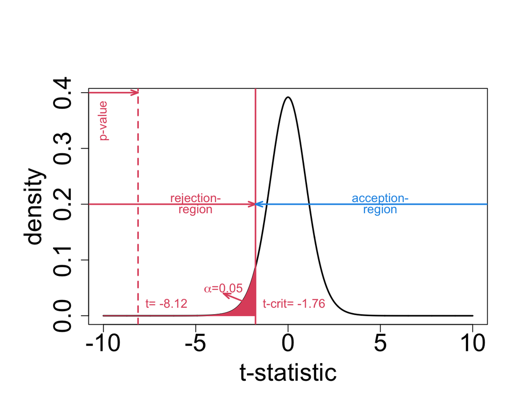

## 5.6 Beslissingsfouten

De beslissing om $H_0$ te accepteren of te verwerpen wordt genomen op basis van een enkele steekproef. Er kan een verkeerde beslissing zijn genomen.

| Conclusion | Reality H0 | Reality H1 |
| --- | --- | --- |
| Accept H0 | OK | Type II (β) |
| Reject H0 | Type I (α) | OK |

- Type I error, $\alpha$: de nul hypothese wordt ten onrechte verworpen (vals positief)
- Type II error, $\beta$: de nulhypothese wordt ten onrechte aanvaard
- Beslissing is ook stochastisch! Zie eerste hoofdstuk van de cursus

### 5.6.1 Captopril Voorbeeld

- $H_0$: Het toedienen van captopril heeft geen effect op de systolische bloeddruk
- $H_1$: Het toedienen van captopril leidt gemiddeld tot een verlaging van de bloeddruk
- **Type I error**: er is gemiddeld geen bloeddrukdaling bij toediening van captopril, maar we concluderen dat er een effect is van captopril.
- **Type II error**: er is gemiddeld een bloeddrukdaling bij toediening van captopril, maar deze wordt niet opgemerkt door de statistische test.

### 5.6.2 Type I fout wordt gecontroleerd

De type I-fout wordt gecontroleerd door de constructie van de statistische test.

$$\text{P}\left[\text{type I error}\right]=\text{P}\left[\text{reject }H_0 \mid H_0\right] = \text{P}_0\left[T<t_{n-1;1-\alpha}\right]=\alpha$$

- Het significantieniveau $\alpha$ is de kans om een type I-fout te maken.
- De statistische test zorgt ervoor dat de kans op een type I-fout wordt gecontroleerd op het significantieniveau $\alpha$.
- De kans om $H_0$ correct te accepteren is $1-\alpha$.
- We kunnen aantonen dat de p-waarde onder $H_0$ uniform verdeeld is.
- Het testen van statistische hypothesen leidt dus tot een uniforme beslissingsstrategie.

We illustreren dit in een simulatiestudie

```r
set.seed(1524)
nsim <- 10000
n <- 15
sigma <- 9
mu <- 0
mu0 <- 0
alpha <- 0.05

#simulate nsim samples of size n
deltaSim <- matrix(
  rnorm(n*nsim,mu,sigma),
  nrow=n,
  ncol=nsim)

pSim <- apply(
  deltaSim,
  2,
  function(x, mu, alternative)
    t.test(x,
      mu = mu,
      alternative = alternative)$p.value,
      mu = mu0,
      alternative="less"
  )

mean(pSim<alpha)
```

```
[1] 0.0533
```

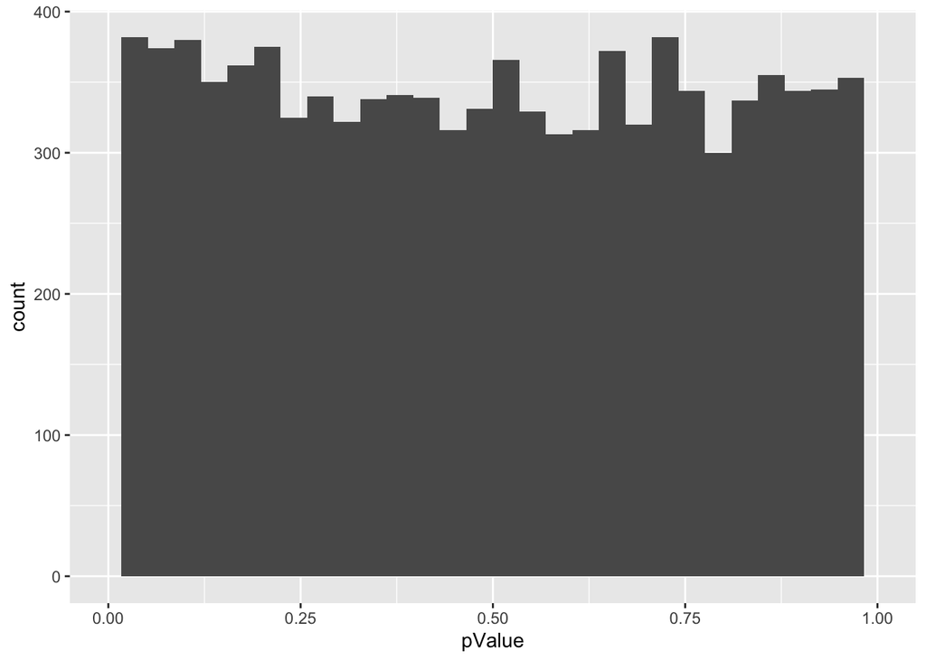

```r
data.frame(pValue = pSim) |>
  ggplot(aes(x=pValue)) +
  geom_histogram() +
  xlim(0,1)
```

- De type I-fout is inderdaad ongeveer 0,05
- De p-waarden zijn uniform

Wat als we de steekproef vergroten?

```r
nsim <- 10000
n <- 30
sigma <- 9
mu <- 0
mu0 <- 0
alpha <- 0.05

#simulate nsim samples of size n
deltaSim <- matrix(
  rnorm(n*nsim,mu,sigma),
  nrow=n,
  ncol=nsim)

pSim <- apply(
  deltaSim,
  2,
  function(x, mu, alternative)
    t.test(x,
      mu = mu,
      alternative = alternative)$p.value,
      mu = mu0,
      alternative="less"
  )

mean(pSim<alpha)
```

```
[1] 0.0474
```

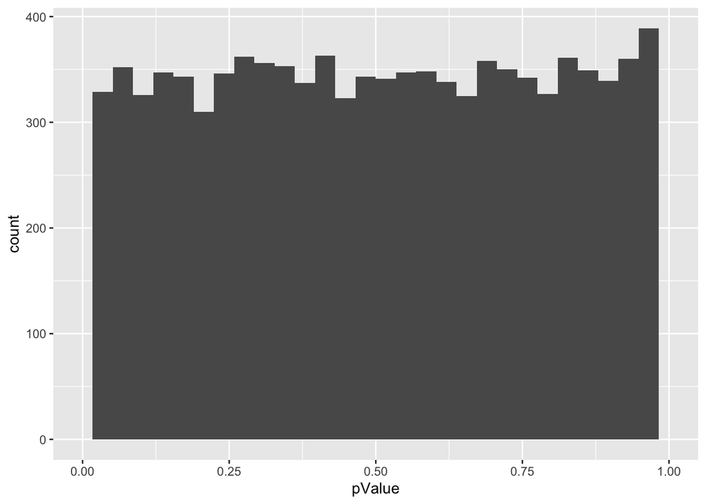

```r
data.frame(pValue = pSim) |>
  ggplot(aes(x=pValue)) +
  geom_histogram() +
  xlim(0,1)
```

- De type I-fout is opnieuw ongeveer 0,05
- De p-waarden zijn uniform

### 5.6.3 Type II fout

- Type II-fout bepalen is minder duidelijk.
- We moeten redeneren onder $H_1$
- In the captopril voorbeeld is $H_1: \mu<0$
- Er zijn veel mogelijke alternatieven
- De verdeling onder $H_1$ is niet volledig gespecificeerd
- *oplossing:* kies een specifieke distributie onder $H_1$.

$$H_1(\delta): \mu=0-\delta \text{ for }\delta>0.$$

```r
nsim <- 10000
n <- 15
sigma <- 9
mu <- -2
mu0 <- 0
alpha <- 0.05

#simulate nsim samples of size n
deltaSim <- matrix(
  rnorm(n*nsim, mu, sigma),
  nrow=n,
  ncol=nsim)

pSim <- apply(
  deltaSim,
  2,
  function(x,mu,alternative)
    t.test(x,
      mu = mu,
      alternative = alternative)$p.value,
      mu = mu0,
      alternative = "less"
  )

mean(pSim<alpha)
```

```
[1] 0.2013
```

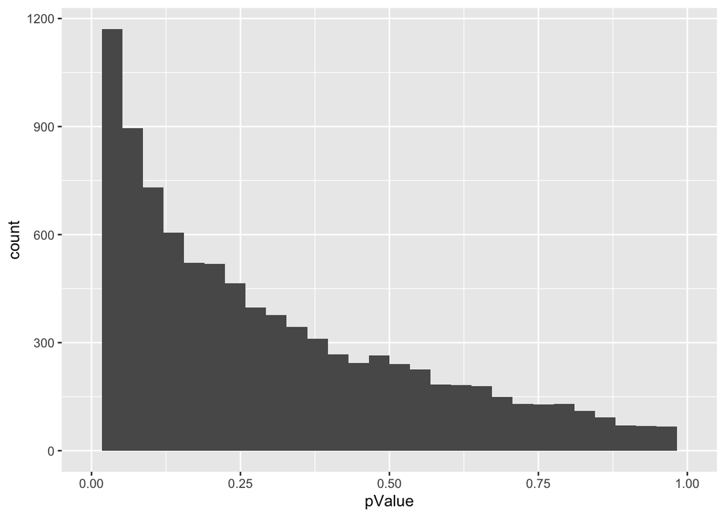

```r
data.frame(pValue = pSim) |>
  ggplot(aes(x=pValue)) +
  geom_histogram() +
  xlim(0,1)
```

- We observeren dat een power van 0.2013 of een type II error van 0.7987.
- Wanneer we de steekproefgrootte vergroten

```r
nsim <- 10000
n <- 30
sigma <- 9
mu <- -2
mu0 <- 0
alpha <- 0.05

#simulate nsim samples of size n
deltaSim <- matrix(
  rnorm(n*nsim, mu, sigma),
  nrow=n,
  ncol=nsim)

pSim <- apply(
  deltaSim,
  2,
  function(x,mu,alternative)
    t.test(x,
      mu = mu,
      alternative = alternative)$p.value,
      mu = mu0,
      alternative = "less"
  )

mean(pSim < alpha)
```

```
[1] 0.3316
```

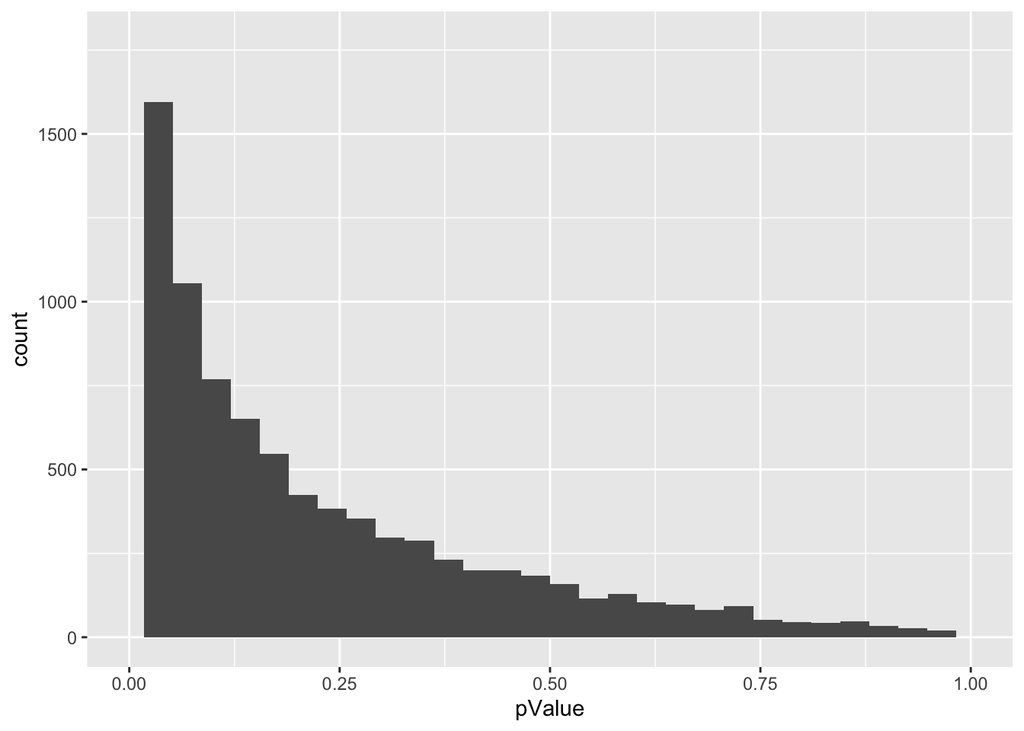

```r
data.frame(pValue = pSim) |>
  ggplot(aes(x=pValue)) +
  geom_histogram() +
  xlim(0,1)
```

- Het vergroten van de steekproefgrootte leidt tot een hogere power.
- Toch blijft de power om zo’n kleine bloeddrukdaling op te vangen erg laag.
- Een daling van 2 mmHg is ook niet relevant voor farmaceutische bedrijven.

[figure not shown]

### 5.6.4 Interpretatie

Stel dat een bepaalde steekproef $p < \alpha$, d.w.z. $H_0$ afwijzen

- Twee mogelijkheden
  - Correcte beslissing,
    - of type I fout.
- We weten dat de kans op een type-I fout klein is, d.w.z. $\alpha=0.05$.

Aan de andere kant als $p\geq\alpha$ en we $H_0$ niet afwijzen hebben we ook twee opties:

- Correcte beslissing,
- of we hebben een type II fout gemaakt.

De kans op een type II fout ($\beta$) wordt niet gecontroleerd op een specifieke waarde.

Statistische test is geconstrueerd om alleen de kans op een type I-fout op $\alpha$ te controleren.

Om wetenschappelijk correct te zijn, moeten we een pessimistische houding aannemen en moeten we toegeven dat $\beta$ groot kan zijn (d.w.z. een kleine power om het alternatief te detecteren).

Dus,

- $p < \alpha$ we verwerpen $H_0$
  - We concluderen dat $H_1$ waarschijnlijk correct is
    - We noemen dit een sterke conclusie
- $p \geq \alpha$ accepteer $H_0$
  - Betekent niet dat we $H_0$ correct accepteren.
  - We kunnen enkel concluderen dat de gegevens onvoldoende bewzijs hebben tegen de $H_0$ in voordeel van $H_1$.
  - Dit noemen we een zwakke conclusie
  - We concluderen doorgaans dat het effect van de behandeling niet significant is.

## 5.7 Conclusies captopril voorbeeld

De test die we hebben uitgevoerd, wordt aangeduid als

- De **enkele steekproef t-test** op het verschil of
- een **gepaarde t-test**. We beschikken inderdaad over gepaarde observaties voor elke patiënt.
- De test is eenzijdig gedaan omdat we testen tegen het alternatief van een bloeddrukdaling.
- Beide tests (één voorbeeld van een t-test op het verschil en een gepaarde t-test) geven dezelfde resultaten:

```r
t.test(captopril$deltaSBP,alternative="less")
```

```
    One Sample t-test

data:  captopril$deltaSBP
t = -8.1228, df = 14, p-value = 5.732e-07
alternative hypothesis: true mean is less than 0
95 percent confidence interval:
      -Inf -14.82793
sample estimates:
mean of x
-18.93333
```

```r
t.test(captopril$SBPa,captopril$SBPb,paired=TRUE,alternative="less")
```

```
    Paired t-test

data:  captopril$SBPa and captopril$SBPb
t = -8.1228, df = 14, p-value = 5.732e-07
alternative hypothesis: true mean difference is less than 0
95 percent confidence interval:
      -Inf -14.82793
sample estimates:
mean difference
      -18.93333
```

### 5.7.1 Conclusie

Er is gemiddeld een extreem significante bloeddrukdaling bij toediening van captopril aan patiënten met hypertensie. De systolische bloeddruk daalt gemiddeld met 18,9 mmHg bij de behandeling met captopril (95% CI [$-\infty,-14.82$] mmHg).

Let op dat

1. Er wordt een eenzijdig interval gerapporteerd omdat we alleen geïnteresseerd zijn in een bloeddrukdaling.
2. Vanwege de pretest / posttest opzet kunnen we geen onderscheid maken tussen het effect van de behandeling en een placebo-effect. Er was geen goede controle! Het ontbreken van een goede controle komt meestal voor bij pre-test / post-test designs. Hoe hadden we het design kunnen verbeteren?

## 5.8 eenzijdig or tweezijdige testen?

De test in het captopril-voorbeeld was een eenzijdige test. We proberen alleen te detecteren of de captoprilbehandeling gemiddeld de bloeddruk verlaagt.

Stel dat we het bloeddrukverschil hebben gedefinieerd als $X_{i}^\prime=Y_{i}^\text{before}-Y_{i}^\text{after}$

- Nu duidt een positieve waarde op een bloeddrukdaling
- De gemiddelde verandering in bloeddruk wordt nu aangeduid als $\mu^\prime=\text{E}[X^\prime]$.
- Dus nu moeten we een eenzijdige test gebruiken om $H_0: \mu^\prime=0$ te beoordelen tegen $H_1: \mu^\prime>0$.
- p-waarde wordt nu:
  $$p=\text{P}_0\left[T\geq t\right].$$

Analyse gebaseerd op $X^\prime$: Argument `alternative="greater"` Zo dat we $H_1: \mu^\prime>0$ gebruiken:

```r
t.test(captopril$SBPb-captopril$SBPa, alternative="greater")
```

```
    One Sample t-test

data:  captopril$SBPb - captopril$SBPa
t = 8.1228, df = 14, p-value = 5.732e-07
alternative hypothesis: true mean is greater than 0
95 percent confidence interval:
 14.82793      Inf
sample estimates:
mean of x
 18.93333
```

Natuurlijk behalen we dezelfde resultaten. Alleen het teken is verwisseld.

### 5.8.1 Tweezijdige test

Stel dat onderzoekers het werkingsmechanisme van het nieuwe medicijn captopril in de ontwerpfase wilden beoordelen en veronderstel dat gezonde proefpersonen in een vroege fase van de medicijnontwikkeling werden gebruikt.

In dit geval zou het interessant zijn geweest om zowel bloeddrukdalingen als stijgingen waar te nemen.

Dan hebben we een tweezijdige teststrategie nodig

$$H_0: \mu=0$$
tegen de alternatieve hypothese

$$H_1: \mu\neq0,$$

zodat het gemiddelde onder het alternatief verschilt van nul.

Het kunnen zowel positieve als negatieve veranderingen zijn en we wisten van tevoren niet in welke richting het werkelijke gemiddelde zal afwijken van $H_1$.

We kunnen een tweezijdige test uitvoeren op het $\alpha=5\%$ significantieniveau door

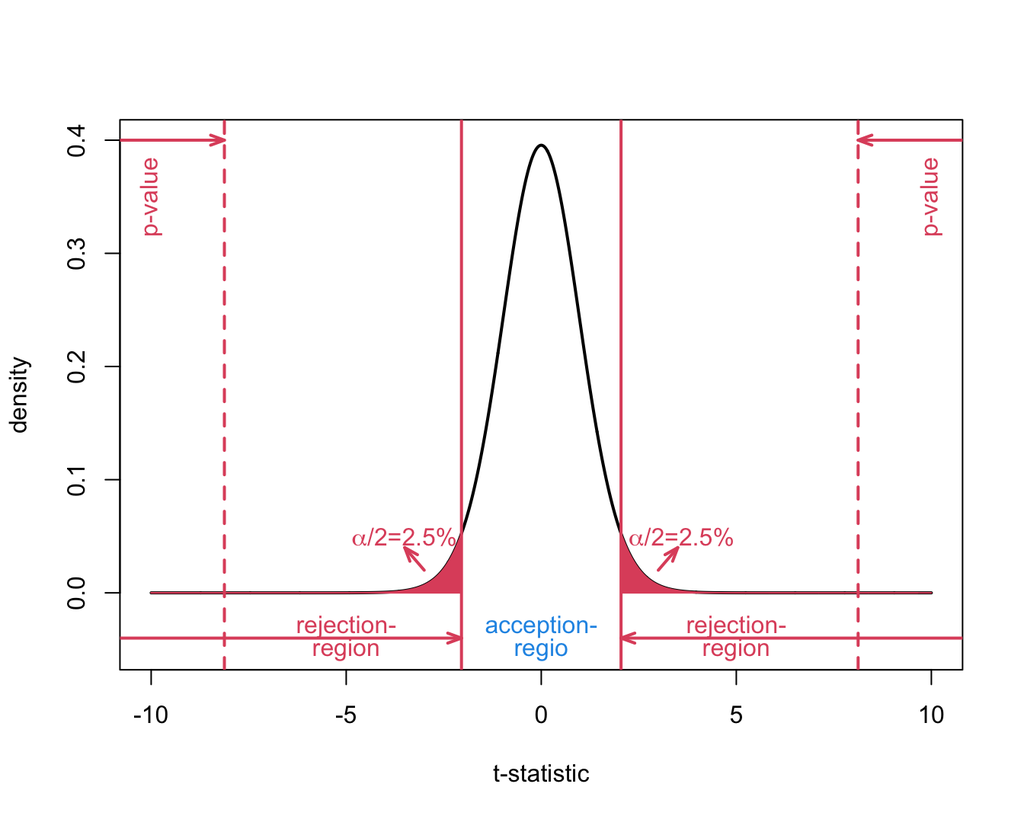

Het argument `alternative` van de `t.test` functie is heeft default waarde `alternative="two.sided"`.

```r
t.test(captopril$deltaSBP)
```

```
    One Sample t-test

data:  captopril$deltaSBP
t = -8.1228, df = 14, p-value = 1.146e-06
alternative hypothesis: true mean is not equal to 0
95 percent confidence interval:
 -23.93258 -13.93409
sample estimates:
mean of x
-18.93333
```

- We behalen nog steeds een buitengewoon significant resultaat.
- De p-waarde is dubbel zo groot omdat we tweezijdig testen.

Inderdaad

$$p=P_0[T \leq -\vert t \vert] + P_0[T \geq \vert t \vert] = P_0[\vert T \vert \geq \vert t \vert] = 2 \times P_0[T \geq \vert t \vert]$$

- We verkrijgen ook een tweezijdig betrouwbaarheidsinterval

### 5.8.2 Eénzijdige of tweezijdige test?

Met een eenzijdige test kunnen we $H_0$ gemakkelijker afwijzen op voorwaarde dat $H_1$ waar is dan met een tweezijdige test.

- Alle informatie wordt gebruikt om in één richting te testen
- De beslissing om eenzijdig te testen moet in de ontwerpfase worden genomen voordat het experiment wordt uitgevoerd
- Zelfs als we sterke a priori aannames hebben, zijn we er niet helemaal zeker van, anders zouden we geen reden hebben om het onderzoek te doen.
- Als we in de ontwerpfase een eenzijdige test voorstellen en we zien een resultaat in tegengestelde richting dat statistisch significant zou zijn, kunnen we geen conclusies trekken uit het experiment.
- In de ontwerpfase hebben we dit resultaat uitgesloten omdat het zo onverwacht is dat het een vals positief moet zijn.
- Daarom worden eenzijdige tests niet aanbevolen.

Een tweezijdige test kan altijd worden verdedigd en stelt u in staat elke afwijking van $H_0$ te detecteren en wordt ten zeerste aanbevolen.

Het is **nooit toegestaan** om een tweezijdige test te veranderen in een eenzijdige test op basis van wat er in de steekproef is waargenomen! Anders wordt de type I-fout van de teststrategie niet correct gecontroleerd.

We illustreren dit in onderstaande simulatiestudie:

1. correcte tweezijdige test en
2. eenzijdige test met zijn teken gebaseerd op wat werd waargenomen in de steekproef.

```r
set.seed(115)
mu <- 0
sigma <- 9.0
nSim <- 1000
alpha <- 0.05
n <- 15

pvalsCor <-
  pvalsInCor <-
  array(0,nSim)

for (i in 1:nSim)
{
    x <- rnorm(n, mean = mu, sd = sigma)
    pvalsCor[i] <- t.test(x)$p.value
    if (mean(x) < 0)
        pvalsInCor[i] <- t.test(x, alternative = "less")$p.value else
        pvalsInCor[i] <- t.test(x, alternative = "greater")$p.value
}

mean(pvalsCor < 0.05)
```

```
[1] 0.049
```

```r
mean(pvalsInCor < 0.05)
```

```
[1] 0.106
```

- Type I-fout correct gecontroleerd op $\alpha$ voor tweezijdige test.
- Type I-fout niet correct gecontroleerd wanneer we eenzijdig testen op basis van wat we in de steekproef hebben waargenomen.

# 6 Nature column over testen

[figure not shown]

# 7 Geclusterde metingen

- Data niet altijd onafhankelijk.
- Consequenties voor schatten van standaard errors

## 7.1 Voorbeeld

- Studiedesign met $n$ planten
- Expressie van bepaald gen wordt 2 maal gemeten
- Men is geïnteresseerd in gemiddelde genexpressie.
- $Y_{i1}$ en $Y_{i2}$ de eerste en tweede meting voor plant $i=1,...,n$:
  $$\begin{equation*}
  \bar Y = \sum_{i=1}^n \frac{Y_{i1}+Y_{i2}}{2n}
  \end{equation*}$$
- Stel planten onafhankelijk
- Eerste en tweede metingen even variabel ()$\text{Var}(Y_{i1})=\text{Var}(Y_{i2})=\sigma^2$)
- Variantie op steekproefgemiddelde:
  $$\begin{eqnarray*}
  \text{Var}(\bar Y)&=&\sum_{i=1}^n \frac{\text{Var}(Y_{i1}+Y_{i2})}{4n^2} \\
  &=&\sum_{i=1}^n \frac{\sigma^2+\sigma^2+2\text{Cor}(Y_{i1},Y_{i2})\sigma^2}{%
  4n^2} \\
  &=&\frac{\sigma^2}{2n}\{1+\text{Cor}(Y_{1},Y_{2})\}
  \end{eqnarray*}$$
- Metingen afkomstig van zelfde plant doorgaans positief met elkaar gecorreleerd zijn
- $SE_{\bar Y}$ dus groter dan bij $2n$ metingen van $2n$ verschillende planten
- Gegeven eerste meting $Y_{i1}$ brengt de tweede meting $Y_{i2}$ geen volledig nieuwe informatie bij
- Er is bijgevolg minder informatie beschikbaar om het gemiddelde te schatten dan wanneer alle gegevens van verschillende planten afkomstig waren.

Wat bij twee extremen:

- Stel dat $\text{Cor}(Y_{1},Y_{2})=1$ tweede meting geen nieuwe informatie en zelfde nauwkeurigheid als wanneer we alleen de n eerste metingen beschouwen
- Wanneer $\text{Cor}(Y_{1},Y_{2})=0$, tweede meting volledig nieuwe informatie en dus eenzelfde nauwkeurigheid als bij 1 meting voor $2n$ i.p.v. $n$ verschillende planten. Vermits

$$\frac{\sigma^2}{2n}\{1+\text{Cor}(Y_{1},Y_{2})\}\geq \frac{\sigma^2}{2n}$$

*Wanneer de correlatie tussen herhaalde genexpressie metingen positief is (hetgeen we verwachten), zal men in de praktijk meer preciese resultaten bekomen door 1 meting te bepalen voor $2n$ verschillende planten dan door 2 metingen te bepalen voor $n$ verschillende planten.*

- Als er evenveel herhaalde metingen zijn voor elk subject/experimentele unit (vb plant) dan kan men metingen ook reduceren naar $n$ onafhankelijke metingen door het gemiddelde te berekenen per experimentele unit.
- Omdat de gemiddeldes per experimentele unit zijn gebaseerd op evenveel herhaalde metingen zal de precisie van die gemiddeldes hetzelfde zijn.
- Bij verschillend aantal herhaalde metingen per experimentele unit kan men NIET met gemiddeldes per Exp. unit werken want die hebben anders een verschillende precisie $\longrightarrow$ dan zijn meer geavanceerde methoden nodig!

## 7.2 Captopril

- Metingen geclusterd: twee systolische bloeddrukmetingen per patiënt
  - 1 meting voor en
  - 1 meting na het toedienen van captopril.
- Gemiddelde bloeddrukverandering $\mu$ schatten a.d.h.v. gegevens
  $$(Y_{i1} , Y_{i2}),$$
  voor subjecten $i = 1, ..., n$.

$$\bar X = \sum_{i=1}^n \frac{Y_{i2}-Y_{i1}}{n}$$

Uit rekenregels voor variantie:
$$\begin{eqnarray*}
\text{Var}\left[\bar X\right]&=&\sum_{i=1}^n \frac{\text{Var}\left[Y_{i1}-Y_{i2}\right]}{n^2}\\
&=&\sum_{i=1}^n \frac{\sigma^2_1+\sigma^2_2-2\text{Cor}\left[Y_{i1},Y_{i2}\right]\sigma_1\sigma_2}{n^2}\\
&=&\frac{\sigma^2_1+\sigma^2_2-2\text{Cor}\left[Y_{i1},Y_{i2}\right]\sigma_1\sigma_2}{n},\\
\end{eqnarray*}$$

```r
#functie var op een matrix berekent varianties sigma_1^2, sigma_2^2
#covariantie sigma_{12}
vars <- var(captopril[,c("SBPb","SBPa")])
vars
```

```
         SBPb     SBPa
SBPb 422.9238 370.7857
SBPa 370.7857 400.1429
```

```r
cor(captopril$SBPa,captopril$SBPb)
```

```
[1] 0.9013312
```

```r
varXbarDelta <- (vars[1,1]+vars[2,2]-2*vars[1,2])/15
sqrt(varXbarDelta)
```

```
[1] 2.330883
```

- Metingen heel sterk gecorreleerd. Variantie op het verschil veel lager dan op de originele metingen!
- alternatieve methode om de standard error te bepalen:
  - gecorreleerde metingen tot 1 meting te reduceren
  - kan enkel voor design met gepaarde metingen (2 metingen per patient)
  - Alle verschillen zijn onafhankelijk.

    $$X_{i}=Y_{ai}-Y_{bi}$$
  - vervolgens standard error op $\bar X$.

In het captopril voorbeeld wordt de schatting

```r
sd(captopril$deltaSBP)/sqrt(15)
```

```
[1] 2.330883
```

- Exact dezelfde schatting voor standard error
- Groot voordeel van design:
  - bloeddrukmetingen voor en na sterk positief gecorreleerd $\longrightarrow$ variantie van verschil veel lager dan dat op originele bloeddrukmetingen
  - Iedere patiënt dient immers als zijn eigen controle
  - We kunnen variabiliteit in bloeddrukmetingen tussen patiënten uit de analyse verwijderen!
- Een gepaard experiment is speciale vorm van randomized complete block design:
  - Elke persoon is een blok en
  - Elke behandeling getest blok: een controle bloeddrukmeting en een bloeddrukmeting na toedienen van captopril
  - Er is een grote variabiliteit tussen blokken! $\longrightarrow$ Bloeddruk hoog voor meestal ook bloeddruk hoog na captopril behandeling.
  - standaarddeviatie in bloeddruk tussen patienten voor toedienen van captopril bedraagt 20.6 mmHg.
  - Effect van captopril schatten binnen patient.
  - Door het blokdesign variabiliteit tussen patiënten uit de analyse weren.
  - Voor een gepaard design kan dat door b.v. analyse op bloeddrukverschillen.
  - Standaard error op bloeddruk verschillen tussen patiënten is inderdaad veel lager 9.03.
  - Voor blok design met meer metingen per blok analyse met meervoudig regressie model (Hoofdstuk 10).

Hoe kunnen we het captopril experiment verder verbeteren?